# WDFW Hatchery Program Performance Evaluation: Lewis River Spring Chinook

Author

Affiliation

Matt Siskey

Washington Department of Fish & Wildlife

Published

November 20, 2026

Abstract

Keywords

Pacific salmon, smolt-adult-return, coded-wire tags

# 1 Setup

## 1.1 Background

This script uses WDFW hatchery coded wire tag (CWT) release and return data to calculate run-specific smolt-adult return (SAR), fit an SAR model, and calculate smolt-adult-survival (SAS) for Pacific salmon species. Tables are generated below that display user-specified parameters for query and analysis, location_code information associated with the query parameters set, release location for data incorporated in the SAR/SAS calculation, and the tag codes for fish included by brood year. The location_code information for associated systems/programs is based on a metadata ruleset constructed by the developers in conjunction with hatchery staff, and new queries will require additions to this ruleset for smooth data processing and model fitting.

CWT-based release and recovery data are pulled from the Pacific States Marine Fisheries Commission’s (PSMFC) Regional Marking Information System (RMIS) database. Release data are pulled for the query parameters set by the user (e.g., species, run, hatchery_location_code), categorized by stage-at-release (only smolts retained; method explained below), filtered for years of interest and CWT-tagged groups (i.e., tag_code_or_release_id beginning with “!” are removed), and then the tag codes remaining are used to pulled recovery data. An cwt_released column is created in the release data by combining cwt_1st_mark_count and cwt_2nd_mark_count, and julian day is calculated from first_release_date. Release counts (“cwt_released”) are then aggregated by run, brood year, release location, tag code, julian day, and weight-at-release. Tag code groups that do not have one of these data types are removed. The estimated number of recoveries (number_cwt_estimated) is reported by tag_code, so only grouped data are available. Release year and recovery year are used to calculate age-at-recovery, and this age is used to filter the recovery data for adults (e.g., age-3+ in Region 5). Release and return data are then paired and categorized by release size (i.e., length and weight), date, location, and coded-wire-tag codes. Together, these filtered release and recovery data are used to calculate fate-specific SARs. A table is generated below that reports the release_location_code information for the filtered data.

To ensure all data employed in SAR/SAS calculations are smolt-release data, releases are categorized by stage using RMIS data queried by the user and information reported in the literature. Quinn (2018) reports length-at-smolt (mm) by species in Table 15.1, which summarizes data from 218 published and unpublished reports. We use these reported values to inform a release stage designation, where the avg_length and avg_weight fields queried are fit to an exponential model and the model fit is used to predict weight-at-smolt. This weight-at-smolt is then used to classify release stages, currently implemented as “smolt” if they are larger than the threshold size calculated or “fry_parr” if smaller than it. Given the query-specific nature of this analysis, if program- or system-specific data on size-at-smolt were available, those data could be used directly to inform release_stage classifications.

## 1.2 Pull data & format

### 1.2.1 Settings_Filter

#### 1.2.1.1 Query Parameters

```r
##############################
### Clear workspace & load libraries
# rm(list=ls())

### RMIS coding
# Chinook=1; Coho=2; Steelhead=3; sockeye=4; chum=5; pink=6
# spring == 1; summer == 2; fall == 3; winter == 4
# First-time rmisr install
# options(download.file.method = "wininet")
# devtools::install_github("MattCallahan-NOAA/rmisr", force=TRUE)

# Load packages, several aren't used in this workflow
pacman::p_load(rmisr, httr, magrittr, dplyr, purrr, stringr, tidyverse, knitr, kableExtra, ggplot2, plotly,
               RColorBrewer, jsonlite, janitor, keyring, mgcv, here, lubridate, tidygam, ggeffects, readr)

# Supply API key through keyring to access RMIS server & maintain credential security
token <- key_get("rmis_api")

##############################
### Set up drives & controls
my_drive    <-paste0("C:/Users/sism1477/OneDrive - Washington State Executive Branch Agencies/")
share_drive <-paste0(my_drive,"DFW-Team FP Westside Hatchery MandE - R/")
proj_drive  <-paste0(share_drive,"psalmon_sar_sas/")
`%nin%`     <-negate(`%in%`) # create an exclude operator
source(paste0(proj_drive,"functions/functions.R",sep="")) #Source functions for use below

fishery_id         <-read.csv(paste0(proj_drive,"data/fishery.csv",sep=""))
fishery_id$fishery <-as.character(fishery_id$fishery)
ruleset            <-read.csv(paste0(proj_drive,"data/hatchery_program_ruleset.csv",sep=""), fileEncoding = "latin1", check.names=F)

param_tab <-data.frame(params=c("system","species","run","adult_age","start_yr","end_yr"),
                       value=c(params$system,params$sp,params$run,params$adult_age,params$yr_start,params$yr_end))

param_tab %>%
  kbl(format="html", row.names = NA)%>%
  kable_classic(position="left", html_font = "Cambria")%>%
  kable_styling(full_width = F, bootstrap_options = c("condensed")) #%>% pack_rows(index = table(sar_df$brood_year))
##### Pull data from RMIS & format for use below
hatcheries <-unique(filter(ruleset, system == params$system & loc_col == "hatchery_location_code")$loc_code)

pull_RMIS_dfs <-pull_RMIS()
```

[output not shown]

[output not shown]

[output not shown]

[output not shown]

[output not shown]

[output not shown]

[output not shown]

[output not shown]

[output not shown]

[output not shown]

[output not shown]

[output not shown]

[output not shown]

[output not shown]

[output not shown]

[output not shown]

[output not shown]

[output not shown]

[output not shown]

[output not shown]

[output not shown]

[output not shown]

[output not shown]

[output not shown]

[output not shown]

[output not shown]

[output not shown]

[output not shown]

[output not shown]

[output not shown]

[output not shown]

[output not shown]

[output not shown]

[output not shown]

[output not shown]

[output not shown]

[output not shown]

[output not shown]

[output not shown]

[output not shown]

[output not shown]

[output not shown]

[output not shown]

[output not shown]

[output not shown]

[output not shown]

[output not shown]

[output not shown]

[output not shown]

[output not shown]

[output not shown]

[output not shown]

[output not shown]

[output not shown]

[output not shown]

[output not shown]

[output not shown]

[output not shown]

[output not shown]

[output not shown]

[output not shown]

[output not shown]

[output not shown]

[output not shown]

[output not shown]

[output not shown]

[output not shown]

[output not shown]

[output not shown]

[output not shown]

[output not shown]

[output not shown]

[output not shown]

[output not shown]

[output not shown]

[output not shown]

[output not shown]

[output not shown]

[output not shown]

[output not shown]

[output not shown]

[output not shown]

[output not shown]

[output not shown]

[output not shown]

[output not shown]

[output not shown]

[output not shown]

[output not shown]

[output not shown]

[output not shown]

[output not shown]

[output not shown]

[output not shown]

[output not shown]

[output not shown]

[output not shown]

[output not shown]

[output not shown]

[output not shown]

[output not shown]

[output not shown]

[output not shown]

[output not shown]

[output not shown]

[output not shown]

[output not shown]

[output not shown]

[output not shown]

[output not shown]

[output not shown]

[output not shown]

[output not shown]

[output not shown]

[output not shown]

[output not shown]

[output not shown]

[output not shown]

[output not shown]

[output not shown]

[output not shown]

[output not shown]

[output not shown]

[output not shown]

[output not shown]

[output not shown]

[output not shown]

[output not shown]

[output not shown]

[output not shown]

[output not shown]

[output not shown]

[output not shown]

[output not shown]

[output not shown]

[output not shown]

[output not shown]

[output not shown]

[output not shown]

[output not shown]

[output not shown]

[output not shown]

[output not shown]

[output not shown]

[output not shown]

[output not shown]

[output not shown]

[output not shown]

[output not shown]

[output not shown]

[output not shown]

[output not shown]

[output not shown]

[output not shown]

[output not shown]

[output not shown]

[output not shown]

[output not shown]

[output not shown]

[output not shown]

[output not shown]

[output not shown]

[output not shown]

[output not shown]

[output not shown]

[output not shown]

[output not shown]

[output not shown]

[output not shown]

[output not shown]

[output not shown]

[output not shown]

[output not shown]

[output not shown]

[output not shown]

[output not shown]

[output not shown]

[output not shown]

[output not shown]

[output not shown]

[output not shown]

[output not shown]

[output not shown]

[output not shown]

[output not shown]

[output not shown]

[output not shown]

[output not shown]

[output not shown]

[output not shown]

[output not shown]

[output not shown]

[output not shown]

[output not shown]

[output not shown]

[output not shown]

[output not shown]

[output not shown]

[output not shown]

[output not shown]

[output not shown]

[output not shown]

[output not shown]

[output not shown]

[output not shown]

[output not shown]

[output not shown]

[output not shown]

[output not shown]

[output not shown]

[output not shown]

[output not shown]

[output not shown]

[output not shown]

[output not shown]

[output not shown]

[output not shown]

[output not shown]

[output not shown]

[output not shown]

[output not shown]

[output not shown]

[output not shown]

[output not shown]

[output not shown]

[output not shown]

[output not shown]

[output not shown]

[output not shown]

[output not shown]

[output not shown]

[output not shown]

[output not shown]

[output not shown]

[output not shown]

[output not shown]

[output not shown]

[output not shown]

[output not shown]

[output not shown]

[output not shown]

[output not shown]

[output not shown]

```r
len_wt_df     <-pull_RMIS_dfs$len_wt_df
sar_df_pull   <-pull_RMIS_dfs$sar_df_pull
smolt_mm      <-pull_RMIS_dfs$smolt_mm
loc_all       <-pull_RMIS_dfs$loc_all
rel_agency    <-pull_RMIS_dfs$report_rel_rel
rec_agency    <-pull_RMIS_dfs$report_samp_rec
tag_rate_df   <-pull_RMIS_dfs$tag_rate_df
```

Table 1: Parameter values set in the YAML header defining which data are being pulled from RMIS for calculation of SAR and SAS.

| params | value |
| --- | --- |
| system | r5_lewis |
| species | 1 |
| run | 1 |
| adult_age | 3 |
| start_yr | 1970 |
| end_yr | 2021 |

#### 1.2.1.2 Location code ruleset

```r
if(params$run!="NA"){
  ruleset %>%
    filter(., system==params$system) %>%
    filter(., species==params$sp) %>%
    filter(., run==params$run) %>%
    # rename("month" = first_release_date_month) %>%
    # arrange(brood_year, month,avg_weight) %>%
    # select(-brood_year)%>%
    kbl(format="html", row.names = NA)%>%
    kable_classic(position="left", html_font = "Cambria")%>%
    kable_styling(full_width = F, bootstrap_options = c("condensed")) #%>% pack_rows(index = table(sar_df$brood_year))
}
if(params$run=="NA"){
  ruleset %>%
    filter(., system==params$system) %>%
    filter(., species==params$sp) %>%
    filter(., is.na(run)) %>%
    # rename("month" = first_release_date_month) %>%
    # arrange(brood_year, month,avg_weight) %>%
    # select(-brood_year)%>%
    kbl(format="html", row.names = NA)%>%
    kable_classic(position="left", html_font = "Cambria")%>%
    kable_styling(full_width = F, bootstrap_options = c("condensed")) #%>% pack_rows(index = table(sar_df$brood_year))
}
```

Table 2: Hatchery, stock, and release location information for the query parameters set by the user.

| species | run | loc_code | loc_col | name | region | system |
| --- | --- | --- | --- | --- | --- | --- |
| 1 | 1 | 3F42001^^270168^H | hatchery_location_code | LEWIS RIVER HATCHERY | 5 | r5_lewis |
| 1 | 1 | 3F42001^^270168^R | release_location_code | LEWIS R 27.0168 | 5 | r5_lewis |
| 1 | 1 | 3F42001^^270168^R01 | release_location_code | LEWIS R -NF 27.0168 | 5 | r5_lewis |
| 1 | 1 | 3F42001^^270168^R02 | release_location_code | LK MERWIN (27) | 5 | r5_lewis |
| 1 | 1 | 3F42001^^270168^S | stock_location_code | LEWIS R 27.0168 | 5 | r5_lewis |
| 1 | 1 | 3F42001^^270168^S04 | stock_location_code | LEWIS RIVER HATCHERY | 5 | r5_lewis |
| 1 | 1 | 3F42001^^270430^H | hatchery_location_code | SPEELYAI HATCHERY | 5 | r5_lewis |
| 1 | 1 | 3F42001^^270430^H | hatchery_location_code | SPEELYAI HATCHERY | 5 | r5_lewis |

#### 1.2.1.3 Release locations

```r
rel_loc_filter <-as.data.frame(table(sar_df_pull$release_location_code))
names(rel_loc_filter) <-c("loc_code", "Count")

rel_loc_filter %>%
  left_join(., filter(ruleset, species==params$sp & run==params$run)[,c("loc_code","name")], by="loc_code") %>%
  # filter(., system==params$system) %>%
  # filter(., loc_code %in% unique(sar_df$release_location_code)) %>%
  # rename("month" = first_release_date_month) %>%
  # arrange(brood_year, month,avg_weight) %>%
  # select(-brood_year)%>%
  kbl(format="html", row.names = NA)%>%
  kable_classic(position="left", html_font = "Cambria")%>%
  kable_styling(full_width = F, bootstrap_options = c("condensed")) #%>% pack_rows(index = table(sar_df$brood_year))
```

Table 3: Release location information for pulled RMIS data after filtering for ruleset locations to be used in the following smolt-adult return calculations.

| loc_code | Count | name |
| --- | --- | --- |
| 3F42001^^270168^R | 276 | LEWIS R 27.0168 |
| 3F42001^^270168^R01 | 1058 | LEWIS R -NF 27.0168 |

#### 1.2.1.4 CWT Codes & Tag Rates

```r
# tag_codes <-sar_df %>% distinct(brood_year, tag_code)
#
# tag_codes %>%
#   arrange(brood_year) %>%
#   select(-c(brood_year)) %>%
#   kbl(row.names = NA) %>%
#   kable_classic(position="left",full_width = F, html_font = "Cambria") %>%
#   kable_styling(bootstrap_options = c("condensed")) %>%
#   scroll_box(height = "400px") %>%
#   pack_rows(index = table(tag_codes$brood_year))

tag_rate_df %>%
  rename(month = first_release_date_month) %>%
  arrange(brood_year,month) %>%
  kbl(row.names = NA) %>%
  kable_classic(position="left",full_width = F, html_font = "Cambria") %>%
  kable_styling(bootstrap_options = c("condensed")) %>%
  scroll_box(height = "400px")
```

Table 4: Tag codes and calcualted tagging rates for released fish by brood year that are included in the following analysis.

| species | brood_year | hatchery_location_code | month | tag_code | cwt_released | total_released | tag_rate |
| --- | --- | --- | --- | --- | --- | --- | --- |
| 1 | 1972 | 3F42001^^270430^H | 2 | 151402 | 31302 | 94392 | 0.3316171 |
| 1 | 1972 | 3F42001^^270430^H | 9 | 151407 | 41760 | 104097 | 0.4011643 |
| 1 | 1973 | 3F42001^^270430^H | 2 | 011110 | 19558 | 114907 | 0.1702072 |
| 1 | 1973 | 3F42001^^270430^H | 9 | 011203 | 28006 | 163504 | 0.1712863 |
| 1 | 1978 | 3F42001^^270430^H | 9 | 631920 | 51660 | 423948 | 0.1218546 |
| 1 | 1983 | 3F42001^^270168^H | 9 | 632329 | 97180 | 287000 | 0.3386063 |
| 1 | 1984 | 3F42001^^270168^H | 10 | 633409 | 51572 | 164400 | 0.3136983 |
| 1 | 1984 | 3F42001^^270168^H | 10 | 633410 | 49661 | 164400 | 0.3020742 |
| 1 | 1988 | 3F42001^^270168^H | 4 | 635247 | 113890 | 330600 | 0.3444949 |
| 1 | 1989 | 3F42001^^270168^H | 3 | 631116 | 138310 | 969800 | 0.1426170 |
| 1 | 1990 | 3F42001^^270168^H | 3 | 634240 | 50161 | 916100 | 0.0547549 |
| 1 | 1990 | 3F42001^^270168^H | 3 | 634243 | 52496 | 916100 | 0.0573038 |
| 1 | 1990 | 3F42001^^270430^H | 4 | 634239 | 51147 | 327850 | 0.1560073 |
| 1 | 1991 | 3F42001^^270168^H | 2 | 634212 | 86324 | 660000 | 0.1307939 |
| 1 | 1991 | 3F42001^^270168^H | 3 | 634430 | 39995 | 401000 | 0.0997382 |
| 1 | 1992 | 3F42001^^270168^H | 3 | 634948 | 146602 | 1335900 | 0.1097403 |
| 1 | 1993 | 3F42001^^270168^H | 2 | 635253 | 44793 | 420092 | 0.1066266 |
| 1 | 1993 | 3F42001^^270168^H | 2 | 635330 | 99604 | 420092 | 0.2371004 |
| 1 | 1994 | 3F42001^^270168^H | 2 | 635663 | 91941 | 666900 | 0.1378632 |
| 1 | 1994 | 3F42001^^270168^H | 3 | 635643 | 38329 | 455500 | 0.0841471 |
| 1 | 1995 | 3F42001^^270168^H | 3 | 635738 | 49980 | 952868 | 0.0524522 |
| 1 | 1995 | 3F42001^^270168^H | 3 | 636059 | 97170 | 952868 | 0.1019763 |
| 1 | 1996 | 3F42001^^270168^H | 3 | 630343 | 120238 | 952441 | 0.1262419 |
| 1 | 1997 | 3F42001^^270168^H | 3 | 630355 | 67718 | 502472 | 0.1347697 |
| 1 | 1997 | 3F42001^^270168^H | 3 | 630356 | 76615 | 502472 | 0.1524762 |
| 1 | 1997 | 3F42001^^270168^H | 3 | 630519 | 170070 | 502472 | 0.3384666 |
| 1 | 1997 | 3F42001^^270168^H | 3 | 630520 | 175347 | 502472 | 0.3489687 |
| 1 | 1997 | 3F42001^^270168^H | 4 | 630303 | 227850 | 238113 | 0.9568986 |
| 1 | 1998 | 3F42001^^270168^H | 2 | 630315 | 147194 | 149649 | 0.9835949 |
| 1 | 1998 | 3F42001^^270168^H | 3 | 630634 | 144862 | 751722 | 0.1927069 |

[output cut: 92 more lines]

#### 1.2.1.5 FPP Conversion

```r
fpp_g_conversion <-data.frame(fpp = c(1,5,10,20,30,40,50,100),
                              gpf = c(454,90,45,23,15,11,9,5))
colnames(fpp_g_conversion) <-c("fpp","gpf")

fpp_g_conversion %>%
  kbl(row.names = NA) %>%
  kable_classic(position="left",full_width = F, html_font = "Cambria") %>%
  kable_styling(bootstrap_options = c("condensed")) %>%
  scroll_box(height = "400px")
```

Table 5: Conversion table for fish-per-pound to grams-per-fish.

| fpp | gpf |
| --- | --- |
| 1 | 454 |
| 5 | 90 |
| 10 | 45 |
| 20 | 23 |
| 30 | 15 |
| 40 | 11 |
| 50 | 9 |
| 100 | 5 |

### 1.2.2 Length_weight

```r
####################################
### Length-weight relationship for determining stage

# set plotting theme
theme_set(theme_minimal())

### length-weight relationship of unfiltered data
len_wt <- ggplot(len_wt_df, aes(x=avg_length, y=avg_weight, group=as.factor(first_release_date_month), color=as.factor(first_release_date_month))) +
            # geom_line(aes(x = avg_length, y = prediction*100,group=first_release_date_month), linewidth=1) +
            geom_point(pch=21)+
            geom_vline(xintercept=smolt_mm, color="red",linetype="dashed",alpha=0.3)+
            # facet_wrap(.~run, ncol=1)+
            labs(x="Mean Length (mm)", y="Mean Weight (g)", color="Release Month")
ggplotly(len_wt)
```

[interactive chart not shown]

# 2 Results

## 2.1 Methods

### 2.1.1 Methods_text

Smolt-adult-return is calculated for each categorized fate (i.e., hatchery, fishery, and spawning ground) of paired release-recovery data. Below, fate is categorized based on fishery coding, and then fate-specific SARs are reported. These fate-specific SARs are then used below to fit predictive SAR models, and calculate smolt-adult-survival (SAS). Fate is determined by the fishery coding reported for each recovery. Fishery codes range from 10-99, with some additional codes supplied for high seas fishery categories (800-812). Troll (10-19), net & seine (20-29), aboriginal (30-39), sport (40-49), treaty subsitence (56), test (60-69), and high seas (80-89, 800, 802-805, 812) fisheries recoveries are designated as ‘fishery’ fates. In addition, hatchery (50), fish trap (52), broodstock collections (53), and mixed broodstock collection/hatchery returns (57) recoveries are designated as ‘hatchery’ fates, and spawning ground (54) recoveries are designated as ‘spawngr’ fates.

After fate classification, paired release-recovery data are then used to calculate fate-specific SARs. The recovery_location_codes present in the filtered data and the estimated recoveries (number_cwt_estimated) for each recovery location are reported below. There will likely be strays present, but a ‘return to rack’ is desired for the hatchery to inform program performance and broodstock collection. Therefore, these stray fish are filtered out here and will be re-incorporated in a ‘stray’ fate module in later development. Therefore, all hatchery SAR results will be for the list of location_codes categorized as hatchery_location_code in the metadata ruleset from the Setup page. Hatcheries will often vary their rearing treatments to produce fish of different sizes at release or to release fish at different times of the season. Here, we aggregate the filtered hatchery data by the treatment variables size-at-release, release month, release site, and julian day of release. Figures and tables are displayed below to summarize the results.

### 2.1.2 Fate_tile_plot

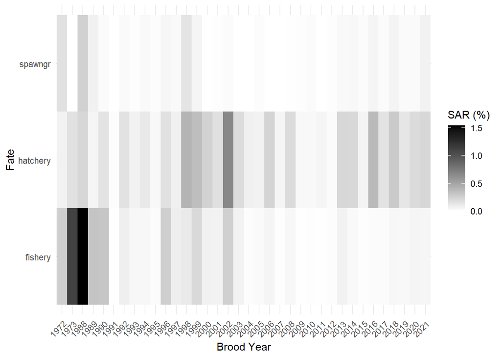

Figure 2: Smolt-adult return calculated collectively across brood year released and recovery fate.

```r
##### Set sar_cwt (cwt-specific sar) or sar_total (tag rate-expanded sar)
if(params$cwt_expanded=="sar_cwt"){
  sar_df <-sar_df_pull %>%
    select(-c(number_cwt_expanded, total_released, sar_total)) %>%
    rename(recoveries = number_cwt_estimated, releases = cwt_released, sar = sar_cwt)
}

if(params$cwt_expanded=="sar_total"){
  sar_df <-sar_df_pull %>%
    select(-c(number_cwt_estimated, cwt_released, sar_cwt)) %>%
    rename(recoveries = number_cwt_expanded, releases = total_released, sar = sar_total)
}


##### Distinguish fates (sar)
### sar by fate category (composed from 'fishery' codes in RMIS, but not all fisheries)
troll        <-seq(10,19,1)
net_seine    <-seq(20,29,1)
aboriginal   <-seq(30,39,1)
sport        <-seq(40,49,1)
esc          <-seq(50,59,1)
test_fishery <-seq(60,69,1)
juv_sampling <-seq(70,79,1) # disregarded
high_sea     <-c(seq(80,89,1),800,802,803,804,805,812)
misc         <-seq(90,99,1) # disregarded

fate_fishery  <-c(troll, net_seine, aboriginal, sport, 56, test_fishery, high_sea, misc)
fate_hatchery <-c(50,52,53,57)
fate_spawngr  <-54

sar_df_fates <-left_join(sar_df, fishery_id, by = "fishery") %>%
               select(-c(sar)) %>%
               aggregate(cbind(releases, recoveries) ~ species + brood_year + release_location_code + hatchery_location_code +
                                                                       first_release_date_month + jday + avg_weight + release_stage_assigned +
                                                                       recovery_location_code + gear + fishery + fishery_name + fishery_short_name +
                                                                       tag_code,
                         data=., FUN=sum) %>%
               mutate(.,fate = case_when(fishery %in% fate_fishery ~ "fishery",
                                         fishery %in% fate_hatchery ~ "hatchery",
                                         fishery %in% fate_spawngr ~ "spawngr"))

sar_df_fates$sar <-sar_df_fates$recoveries/sar_df_fates$releases


### top-level fate returns
# aggregated fate tiles
fate_fig <-sar_df_fates %>%
  select(-c(sar)) %>%
  aggregate(cbind(recoveries) ~ species + brood_year + fate + tag_code + releases, data=., FUN=sum) %>%
  aggregate(cbind(recoveries, releases) ~ species + brood_year + fate, data=., FUN=sum) %>%
  complete(., species, brood_year, fate, fill = list(recoveries = 0, releases = 0))

fate_fig$sar <-(fate_fig$recoveries/fate_fig$releases)
fate_fig[which(fate_fig$sar=="NaN"),"sar"] <-0

ggplot(fate_fig,aes(x=as.factor(brood_year),y=as.factor(fate), fill=sar*100))+
  geom_tile(linewidth=0.5)+
  scale_fill_gradient(low = "white", high = "black")+
  labs(x = "Brood Year", y = "Fate", fill = "SAR (%)")+
  theme(axis.text.x = element_text(angle = 45, hjust = 1))
```

## 2.2 Recoveries_tables_figures

### 2.2.1 Tables

#### 2.2.1.1 Hatchery Rec

```r
hatch_recover      <-unique(filter(sar_df_fates, fate=="hatchery")$recovery_location_code)
hatch_recover_name <-list()

for(i in 1:length(hatch_recover)){
  hatch_recover_name[[i]] <-filter(loc_all, location_code == hatch_recover[i])[1,c("location_code","name","latitude","longitude","psc_region")]
  }

hatch_recover_sum <-aggregate(recoveries~recovery_location_code + brood_year, data=filter(sar_df_fates, fate=="hatchery"),FUN=sum)
hatch_recover_df  <-hatch_recover_name %>% map_df(., ~as.data.frame(.)) %>%
                                           rename("recovery_location_code" = location_code) %>%
                                           left_join(., hatch_recover_sum, by="recovery_location_code") %>%
                                           arrange(desc(recoveries))

hatch_recover_df %>%
  # filter(., location_code %in% hatch_recover) %>%
  # rename("month" = first_release_date_month) %>%
  arrange(.,brood_year, recovery_location_code) %>%
  select(-brood_year)%>%
  kbl(format="html", row.names = NA)%>%
  kable_classic(position="left", html_font = "Cambria")%>%
  kable_styling(full_width = F, bootstrap_options = c("condensed")) %>%
  pack_rows(index = table(hatch_recover_df$brood_year))
```

Table 6: Recovery locations associated with a ‘hatchery’ fate in the filtered data, and the number of estimated recoveries reported for each recovery location.

| recovery_location_code | name | latitude | longitude | psc_region | recoveries |
| --- | --- | --- | --- | --- | --- |
| **1972** |  |  |  |  |  |
| 3F42001^^270430^H | SPEELYAI HATCHERY | 45.9887 | -122.4053 | LOCR | 137.522032 |
| **1973** |  |  |  |  |  |
| 3F42001^^270002^H | KALAMA FALLS HATCHERY | 46.0160 | -122.7336 | LOCR | 11.750383 |
| 3F42001^^270430^H | SPEELYAI HATCHERY | 45.9887 | -122.4053 | LOCR | 438.218411 |
| **1988** |  |  |  |  |  |
| 3F42001^^260002^H02 | COWLITZ SALMON HATCHERY | 46.5113 | -122.6293 | LOCR | 39.449065 |
| 3F42001^^270002^H | KALAMA FALLS HATCHERY | 46.0160 | -122.7336 | LOCR | 40.639213 |
| 3F42001^^270168^H | LEWIS RIVER HATCHERY | 45.9370 | -122.6165 | LOCR | 637.222864 |
| **1989** |  |  |  |  |  |
| 3F42001^^270002^H | KALAMA FALLS HATCHERY | 46.0160 | -122.7336 | LOCR | 28.327612 |
| 3F42001^^270168^H | LEWIS RIVER HATCHERY | 45.9370 | -122.6165 | LOCR | 477.642802 |
| **1990** |  |  |  |  |  |
| 3F42001^^270002^H | KALAMA FALLS HATCHERY | 46.0160 | -122.7336 | LOCR | 49.532093 |
| 3F42001^^270168^H | LEWIS RIVER HATCHERY | 45.9370 | -122.6165 | LOCR | 3212.352993 |
| **1991** |  |  |  |  |  |
| 3F42001^^270168^H | LEWIS RIVER HATCHERY | 45.9370 | -122.6165 | LOCR | 168.607215 |
| **1992** |  |  |  |  |  |
| 3F42001^^270002^H | KALAMA FALLS HATCHERY | 46.0160 | -122.7336 | LOCR | 28.248523 |
| 3F42001^^270168^H | LEWIS RIVER HATCHERY | 45.9370 | -122.6165 | LOCR | 2079.820303 |
| **1993** |  |  |  |  |  |
| 3F42001^^270168^H | LEWIS RIVER HATCHERY | 45.9370 | -122.6165 | LOCR | 574.416540 |
| **1994** |  |  |  |  |  |
| 3F42001^^260002^H02 | COWLITZ SALMON HATCHERY | 46.5113 | -122.6293 | LOCR | 14.507130 |
| 3F42001^^270002^H | KALAMA FALLS HATCHERY | 46.0160 | -122.7336 | LOCR | 14.507130 |
| 3F42001^^270168^H | LEWIS RIVER HATCHERY | 45.9370 | -122.6165 | LOCR | 1316.014375 |
| 3F42001^^270339^R | CEDAR CR 27.0339 | 45.9365 | -122.6174 | LOCR | 0.000000 |
| **1995** |  |  |  |  |  |
| 3F42001^^260002^H02 | COWLITZ SALMON HATCHERY | 46.5113 | -122.6293 | LOCR | 19.064986 |
| 3F42001^^270002^H | KALAMA FALLS HATCHERY | 46.0160 | -122.7336 | LOCR | 9.904257 |

[output cut: 116 more lines]

#### 2.2.1.2 Spawngr Rec

```r
spawngr_recover <-unique(filter(sar_df_fates, fate=="spawngr")$recovery_location_code)
spawngr_recover_name <-list()

for(i in 1:length(spawngr_recover)){
  spawngr_recover_name[[i]] <-filter(loc_all, location_code == spawngr_recover[i])[1,c("location_code","name","latitude","longitude","psc_region")]
}

spawngr_recover_sum <-aggregate(recoveries~recovery_location_code + brood_year, data=filter(sar_df_fates, fate=="spawngr"),FUN=sum)
spawngr_recover_df <-spawngr_recover_name %>% map_df(., ~as.data.frame(.)) %>%
                                          rename("recovery_location_code" = location_code) %>%
                                          left_join(., spawngr_recover_sum, by="recovery_location_code") %>%
                                          arrange(desc(recoveries))

### Table showing release and return locations after data filtering
spawngr_recover_df %>%
  arrange(brood_year, recovery_location_code) %>%
  select(-brood_year) %>%
  kbl(format="html", row.names = NA)%>%
  kable_classic(position="left", html_font = "Cambria")%>%
  kable_styling(full_width = F, bootstrap_options = c("condensed")) %>%
  pack_rows(index = table(spawngr_recover_df$brood_year))
```

Table 7: Recovery locations associated with a ‘spawngr’ fate in the filtered data, and the number of estimated recoveries reported for each recovery location.

| recovery_location_code | name | latitude | longitude | psc_region | recoveries |
| --- | --- | --- | --- | --- | --- |
| **1972** |  |  |  |  |  |
| 3F42001^^270168^R | LEWIS R 27.0168 | 45.8504 | -122.7824 | LOCR | 96.618767 |
| 3F42001^^270430^R | SPEELYAI CR 27.0430 | 45.9736 | -122.4212 | LOCR | 69.796839 |
| **1973** |  |  |  |  |  |
| 3F42001^^270168^R | LEWIS R 27.0168 | 45.8504 | -122.7824 | LOCR | 0.000000 |
| **1988** |  |  |  |  |  |
| 3F42001^^270168^R | LEWIS R 27.0168 | 45.8504 | -122.7824 | LOCR | 229.350303 |
| 3F42001^^270168^R71 | LEWIS R & CEDAR CR | NA | NA | LOCR | 601.924805 |
| **1989** |  |  |  |  |  |
| 3F42001^^270002^R | KALAMA R 27.0002 | 46.0338 | -122.8746 | LOCR | 23.279127 |
| 3F42001^^270168^R | LEWIS R 27.0168 | 45.8504 | -122.7824 | LOCR | 429.822428 |
| 3F42001^^270168^R71 | LEWIS R & CEDAR CR | NA | NA | LOCR | 249.900022 |
| **1990** |  |  |  |  |  |
| 3F42001^^270168^R | LEWIS R 27.0168 | 45.8504 | -122.7824 | LOCR | 491.545328 |
| **1992** |  |  |  |  |  |
| 3F42001^^270168^R | LEWIS R 27.0168 | 45.8504 | -122.7824 | LOCR | 361.945594 |
| **1993** |  |  |  |  |  |
| 3F42001^^270168^R71 | LEWIS R & CEDAR CR | NA | NA | LOCR | 104.282399 |
| **1994** |  |  |  |  |  |
| 3F42001^^270168^R71 | LEWIS R & CEDAR CR | NA | NA | LOCR | 368.361087 |
| **1995** |  |  |  |  |  |
| 3F42001^^270168^R71 | LEWIS R & CEDAR CR | NA | NA | LOCR | 145.847143 |
| **1996** |  |  |  |  |  |
| 3F42001^^270168^R71 | LEWIS R & CEDAR CR | NA | NA | LOCR | 476.307634 |
| **1997** |  |  |  |  |  |
| 3F42001^^270002^R | KALAMA R 27.0002 | 46.0338 | -122.8746 | LOCR | 2.539454 |
| 3F42001^^270168^R71 | LEWIS R & CEDAR CR | NA | NA | LOCR | 310.643902 |
| 3F42001^^270168^R72 | LEWIS R + LEWIS R-NF | 45.8504 | -122.7824 | LOCR | 208.758432 |
| 3F42001^^270339^R | CEDAR CR 27.0339 | 45.9365 | -122.6174 | LOCR | 8.016790 |
| **1998** |  |  |  |  |  |
| 3F42001^^270002^R | KALAMA R 27.0002 | 46.0338 | -122.8746 | LOCR | 3.395707 |
| 3F42001^^270168^R71 | LEWIS R & CEDAR CR | NA | NA | LOCR | 92.219779 |
| 3F42001^^270168^R72 | LEWIS R + LEWIS R-NF | 45.8504 | -122.7824 | LOCR | 1238.709653 |
| **1999** |  |  |  |  |  |
| 3F42001^^270168^R01 | LEWIS R -NF 27.0168 | 45.8504 | -122.7824 | LOCR | 443.966214 |
| 3F42001^^270168^R72 | LEWIS R + LEWIS R-NF | 45.8504 | -122.7824 | LOCR | 102.317474 |
| 3F42001^^270173^R | LEWIS R -EF 27.0173 | 45.8661 | -122.7190 | LOCR | 0.000000 |
| 3F42001^^270339^R | CEDAR CR 27.0339 | 45.9365 | -122.6174 | LOCR | 283.452189 |
| **2001** |  |  |  |  |  |
| 3F42001^^270168^R01 | LEWIS R -NF 27.0168 | 45.8504 | -122.7824 | LOCR | 64.516006 |
| **2002** |  |  |  |  |  |
| 3F42001^^270168^R01 | LEWIS R -NF 27.0168 | 45.8504 | -122.7824 | LOCR | 402.616366 |
| **2003** |  |  |  |  |  |
| 3F42001^^270168^R01 | LEWIS R -NF 27.0168 | 45.8504 | -122.7824 | LOCR | 8.662137 |
| **2005** |  |  |  |  |  |
| 3F42001^^270168^R01 | LEWIS R -NF 27.0168 | 45.8504 | -122.7824 | LOCR | 162.698550 |
| 3F42001^^270339^R | CEDAR CR 27.0339 | 45.9365 | -122.6174 | LOCR | 170.765808 |
| **2007** |  |  |  |  |  |
| 3F42001^^270168^R01 | LEWIS R -NF 27.0168 | 45.8504 | -122.7824 | LOCR | 0.000000 |
| **2008** |  |  |  |  |  |
| 3F42001^^270168^R01 | LEWIS R -NF 27.0168 | 45.8504 | -122.7824 | LOCR | 56.553393 |
| **2009** |  |  |  |  |  |
| 3F42001^^270168^R01 | LEWIS R -NF 27.0168 | 45.8504 | -122.7824 | LOCR | 106.422681 |
| **2010** |  |  |  |  |  |
| 3F42001^^270168^R01 | LEWIS R -NF 27.0168 | 45.8504 | -122.7824 | LOCR | 281.300409 |
| **2012** |  |  |  |  |  |
| 3F42001^^270168^R | LEWIS R 27.0168 | 45.8504 | -122.7824 | LOCR | 77.563089 |
| **2013** |  |  |  |  |  |
| 3F42001^^270168^R | LEWIS R 27.0168 | 45.8504 | -122.7824 | LOCR | 231.133830 |
| **2014** |  |  |  |  |  |
| 3F42001^^270168^R | LEWIS R 27.0168 | 45.8504 | -122.7824 | LOCR | 456.405772 |
| **2015** |  |  |  |  |  |
| 3F42001^^270168^R | LEWIS R 27.0168 | 45.8504 | -122.7824 | LOCR | 45.148169 |
| **2016** |  |  |  |  |  |
| 3F42001^^270168^R | LEWIS R 27.0168 | 45.8504 | -122.7824 | LOCR | 886.533157 |
| **2017** |  |  |  |  |  |
| 3F42001^^270168^R | LEWIS R 27.0168 | 45.8504 | -122.7824 | LOCR | 163.489398 |
| **2018** |  |  |  |  |  |
| 3F42001^^270168^R | LEWIS R 27.0168 | 45.8504 | -122.7824 | LOCR | 1708.055461 |
| **2019** |  |  |  |  |  |
| 3F42001^^270168^R | LEWIS R 27.0168 | 45.8504 | -122.7824 | LOCR | 666.762056 |
| **2020** |  |  |  |  |  |
| 3F42001^^270168^R | LEWIS R 27.0168 | 45.8504 | -122.7824 | LOCR | 646.783214 |
| **2021** |  |  |  |  |  |
| 3F42001^^270168^R | LEWIS R 27.0168 | 45.8504 | -122.7824 | LOCR | 839.410740 |

#### 2.2.1.3 Fishery Rec

```r
fishery_recover <-unique(filter(sar_df_fates, fate=="fishery")$recovery_location_code)
fishery_recover_name <-list()

for(i in 1:length(fishery_recover)){
  fishery_recover_name[[i]] <-filter(loc_all, location_code == fishery_recover[i])[1,c("location_code","name","latitude","longitude","psc_region","psc_basin")]
}

fishery_recover_sum <-aggregate(recoveries~recovery_location_code+fishery+fishery_short_name + brood_year, data=filter(sar_df_fates, fate=="fishery"),FUN=sum)
fishery_recover_df <-fishery_recover_name %>% map_df(., ~as.data.frame(.)) %>%
                                          rename("recovery_location_code" = location_code) %>%
                                          left_join(., fishery_recover_sum, by="recovery_location_code") %>%
                                          arrange(desc(recoveries))

fishery_recover_df$water_type = substr(fishery_recover_df$recovery_location_code, 2, 2)
fishery_recover_df$state <-str_extract(fishery_recover_df$recovery_location_code, "^.")

fishery_recover_df <-fishery_recover_df %>%
  mutate(state_name = case_when(
    state == "1" ~ "AK",
    state == "2" ~ "CAN",
    state == "3" ~ "WA",
    state == "4" ~ "ID",
    state == "5" ~ "OR",
    state == "6" ~ "CA",
    state == "7" ~ "Ocean"
  )
)

fishery_recover_df$stem_trib <-substr(fishery_recover_df$name,1,5)
if(substr(params$system,1,2)=="r5"){
  fishery_recover_df[which(fishery_recover_df$stem_trib!="COL R"),"stem_trib"] <-fishery_recover_df[which(fishery_recover_df$stem_trib!="COL R"),"name"]
}

commercial <-c(10,11,16,20,23,25,test_fishery,high_sea,misc)
treaty <-c(15,17,21,22,23,24,39,55,56)


fishery_recover_df <-fishery_recover_df %>%
  mutate(fishery_type = case_when(
    fishery %in% sport ~ "Sport",
    fishery %in% commercial ~ "Commercial",
    fishery %in% treaty ~ "Treaty",
    fishery %nin% c(sport, commercial, treaty) ~ "Other"
  )
)

### Table showing release and return locations after data filtering
fishery_recover_df %>%
  arrange(brood_year,recovery_location_code) %>%
  select(-c(brood_year,latitude,longitude,stem_trib,fishery,state,psc_region)) %>%
  kbl(format="html", row.names = NA)%>%
  scroll_box(height = "400px") %>%
  kable_classic(position="left", html_font = "Cambria")%>%
  kable_styling(full_width = F, bootstrap_options = c("condensed")) %>%
  pack_rows(index = table(fishery_recover_df$brood_year))
```

Table 8: Recovery locations associated with a ‘fishery’ fate in the filtered data, and the number of estimated recoveries reported for each recovery location.

| recovery_location_code | name | psc_basin | fishery_short_name | recoveries | water_type | state_name | fishery_type |
| --- | --- | --- | --- | --- | --- | --- | --- |
| **1972** |  |  |  |  |  |  |  |
| 2MN06H02E^^^^^^^000 | NTR H02E-000 | NA | Ocean Troll (non-treaty) | 12.064882 | M | CAN | Commercial |
| 2MS02H023^^^^^^^000 | SWTR H023-000 | NA | Ocean Troll (non-treaty) | 23.129086 | M | CAN | Commercial |
| 2MS02H023^^^^^^^059 | SWTR H023-059 | NA | Ocean Troll (non-treaty) | 18.364554 | M | CAN | Commercial |
| 3F42001^^270168^R | LEWIS R 27.0168 | LEWI | Freshwater Sport | 427.320350 | F | WA | Sport |
| 3F42001^^^^^^^^^R64 | C.R.MOUTH-BONNEVILLE | LOCRG | Freshwater Sport | 12.062105 | F | WA | Sport |
| 5F33209^^R2^^^^^13 | COL R ZONE 2 NET | LOCRG | Columbia River Gillnet | 20.656014 | F | OR | Treaty |
| 5F33209^^R3^^^^^13 | COL R ZONE 3 NET | LOCRG | Columbia River Gillnet | 9.347791 | F | OR | Treaty |
| **1973** |  |  |  |  |  |  |  |
| 2MS01H026^^^^^^^094 | NWTR H026-094 | NA | Ocean Troll (non-treaty) | 14.128390 | M | CAN | Commercial |
| 3F42001^^260002^R | COWLITZ R 26.0002 | COWL | Freshwater Sport | 289.363797 | F | WA | Sport |
| 3F42001^^270002^R | KALAMA R 27.0002 | LEWI | Freshwater Sport | 70.354244 | F | WA | Sport |
| 3F42001^^270168^R | LEWIS R 27.0168 | LEWI | Freshwater Sport | 2001.568472 | F | WA | Sport |
| 3F42001^^^^^^^^^R64 | C.R.MOUTH-BONNEVILLE | LOCRG | Freshwater Sport | 23.352710 | F | WA | Sport |
| 3M11413^^872247 | JOHNSON POINT | DES | Estuary Sport | 11.750383 | M | WA | Sport |
| 5F33201^^R1^^^^^12 | BELOW WILLAMETTE SPT | LOCRG | Columbia River Sport | 5.875192 | F | OR | Sport |
| 5F33203^^R204^^^12 | COL R OR SPORT SEC 4 | LOCRG | Columbia River Sport | 132.955589 | F | OR | Sport |
| 5F33203^^R3^^^^^12 | BELOW BNVILLE SPORT | LOCRG | Columbia River Sport | 126.980361 | F | OR | Sport |
| 5F33209^^R1^^^^^13 | COL R ZONE 1 NET | LOCRG | Columbia River Gillnet | 29.166290 | F | OR | Treaty |
| 5F33209^^R2534^^13 | COL R ZONE 4 NET 2534 | LOCRG | Columbia River Gillnet | 270.308188 | F | OR | Treaty |
| 5F33209^^R2^^^^^13 | COL R ZONE 2 NET | LOCRG | Columbia River Gillnet | 20.151908 | F | OR | Treaty |
| 5F33209^^R3^^^^^13 | COL R ZONE 3 NET | LOCRG | Columbia River Gillnet | 104.956263 | F | OR | Treaty |
| **1988** |  |  |  |  |  |  |  |
| 1M1 | AK M 1 | SEAKG | Ocean Troll (non-treaty) | 0.000000 | M | AK | Commercial |
| 1M1NE109^62 | AK M 1 NE 109-62 | SENE | Ocean Troll (non-treaty) | 4.267117 | M | AK | Commercial |
| 1M1NE110 | AK M 1 NE 110 | SENE | Ocean Troll (non-treaty) | 4.644482 | M | AK | Commercial |
| 1M1NE111^5004^^MS | AK M 1 NE 111-50 04 MS | SENE | Ocean Sport | 10.885504 | M | AK | Sport |
| 1M1NESACO | AK M 1 NE SACO | SENE | Commercial Seine | 1.538485 | M | AK | Commercial |
| 1M1NW113 | AK M 1 NW 113 | SENW | Ocean Troll (non-treaty) | 15.820265 | M | AK | Commercial |
| 1M1NW113^41 | AK M 1 NW 113-41 | SENW | Ocean Troll (non-treaty) | 52.250417 | M | AK | Commercial |

[output cut: 808 more lines]

### 2.2.2 Figures

#### 2.2.2.1 Hatchery_Spawngr Rec

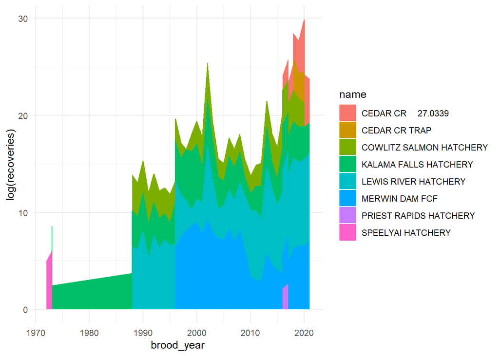

Figure 3: CWT recoveries collected in hatchery operations (rack + weirs) by brood year expanded by tag-rate.

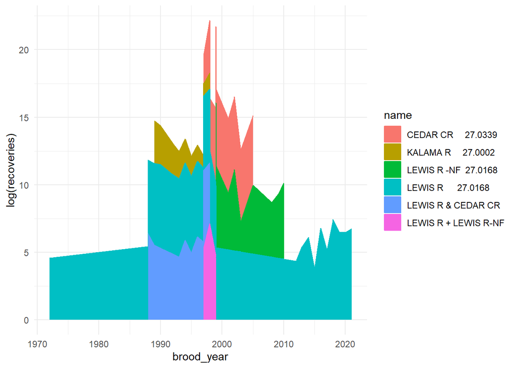

Figure 4: CWT recoveries collected on spawning grounds by brood year expanded by tag-rate.

```r
hatch_rec <-ggplot(data=hatch_recover_df, aes(x=brood_year, y=log(recoveries), group=name, fill=name, color=name))+
  # geom_point(pch=21)+
  # geom_line()
  geom_area()
  # facet_wrap(name~., scales="free_y", ncol=2)
  # facet_grid(name~., scales="free_y")

spawn_rec <-ggplot(data=spawngr_recover_df, aes(x=brood_year, y=log(recoveries), group=name, fill=name, color=name))+
  # geom_point(pch=21)+
  # geom_line()
  geom_area()
  # facet_grid(name~., scales="free_y")
  # facet_wrap(name~., scales="free_y",ncol=2)

print(hatch_rec)
print(spawn_rec)
```

#### 2.2.2.2 Fresh_fishery Rec

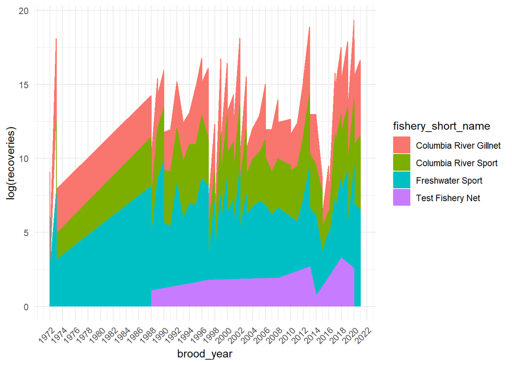

```r
fresh_fishery <-ggplot(data=filter(fishery_recover_df, water_type=="F"), aes(x=brood_year, y=log(recoveries), group=fishery_short_name, fill=fishery_short_name, color=fishery_short_name))+
                  # geom_point()+
                  # geom_line()+
                  geom_area()+
                  # facet_grid(.~fishery_short_name)+
                  # facet_wrap(fishery_short_name~., scales="free_y", ncol=3)+
                  scale_x_continuous(breaks=seq(min(fishery_recover_df$brood_year), 2024, 2))+
                  theme(axis.text.x = element_text(angle = 45, hjust = 1))

cr_gill <-ggplot(data=filter(fishery_recover_df, fishery_short_name=="Columbia River Gillnet"), aes(x=brood_year, y=recoveries))+
            # geom_point()+
            # geom_line()+
            geom_area()+
            facet_wrap(name~., scales="free_y", ncol=3)+
            scale_x_continuous(breaks=seq(min(fishery_recover_df$brood_year), 2024, 2))+
            theme(axis.text.x = element_text(angle = 45, hjust = 1))

cr_sport <-ggplot(data=filter(fishery_recover_df, fishery_short_name=="Columbia River Sport"), aes(x=brood_year, y=recoveries))+
            # geom_point()+
            # geom_line()+
            geom_area()+
            facet_wrap(name~., scales="free_y", ncol=3)+
            scale_x_continuous(breaks=seq(min(fishery_recover_df$brood_year), 2024, 2))+
            theme(axis.text.x = element_text(angle = 45, hjust = 1))

print(fresh_fishery)
# print(cr_gill)
# print(cr_sport)
```

#### 2.2.2.3 Est_Fresh Sport Rec

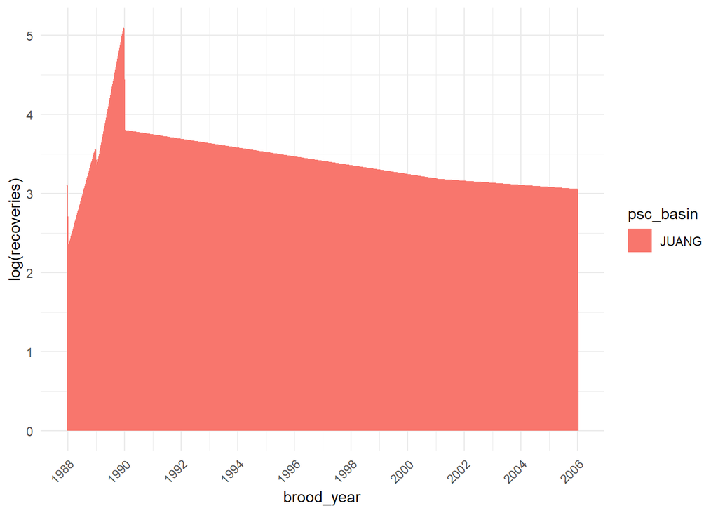

Figure 6: CWT recoveries collected in estuary sport fisheries by brood year expanded by tag-rate.

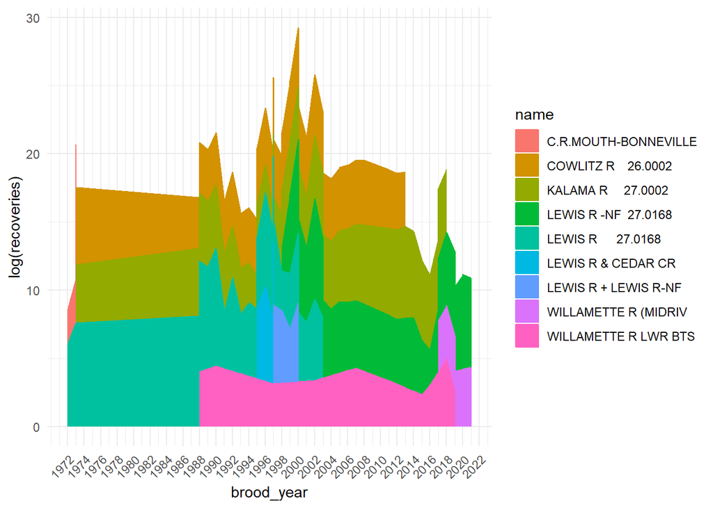

Figure 7: CWT recoveries collected in freshwater sport fisheries by brood year expanded by tag-rate.

```r
est_sport <-ggplot(data=filter(fishery_recover_df, fishery_short_name=="Estuary Sport"), aes(x=brood_year, y=log(recoveries), group=psc_basin, fill=psc_basin, color=psc_basin))+
              # geom_point()+
              # geom_line()+
              geom_area()+
              # facet_wrap(name~., scales="free_y", ncol=3)+
              scale_x_continuous(breaks=seq(min(fishery_recover_df$brood_year), 2024, 2))+
              theme(axis.text.x = element_text(angle = 45, hjust = 1))

fresh_sport <-ggplot(data=filter(fishery_recover_df, fishery_short_name=="Freshwater Sport"), aes(x=brood_year, y=log(recoveries), group=name, fill=name, color=name))+
                # geom_point()+
                # geom_line()+
                geom_area()+
                # facet_wrap(name~., scales="free_y", ncol=3)+
                scale_x_continuous(breaks=seq(min(fishery_recover_df$brood_year), 2024, 2))+
                theme(axis.text.x = element_text(angle = 45, hjust = 1))

print(est_sport)
print(fresh_sport)
```

#### 2.2.2.4 TagRate_Expansion

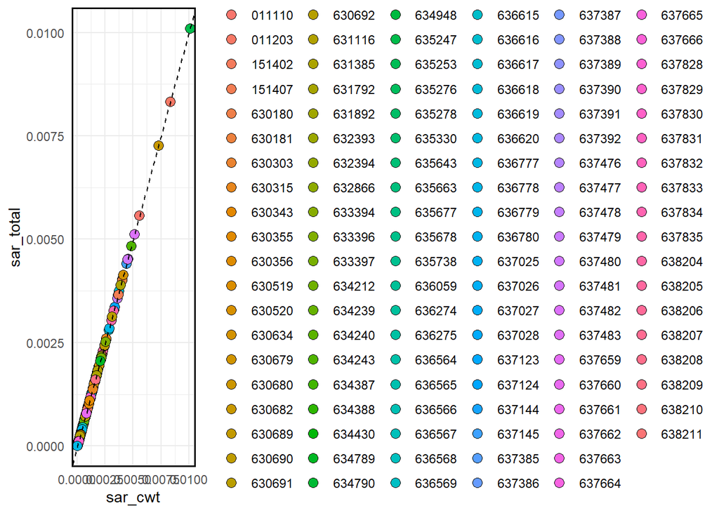

Figure 8: CWT SAR vs. Tag Rate-Expanded SAR by brood year and tag code.

```r
ggplot(sar_df_pull,aes(x=sar_cwt,y=sar_total,group=as.factor(brood_year),fill=as.factor(tag_code)))+
  geom_point(pch=21, size=3)+
  geom_abline(linetype = 2) +
  # facet_grid(brood_year~.)+
  theme(panel.border = element_rect(color = "black", fill = NA, size = 1))
```

## 2.3 SAR_tables_figures

### 2.3.1 Figures

#### 2.3.1.1 Hatchery SAR Figures

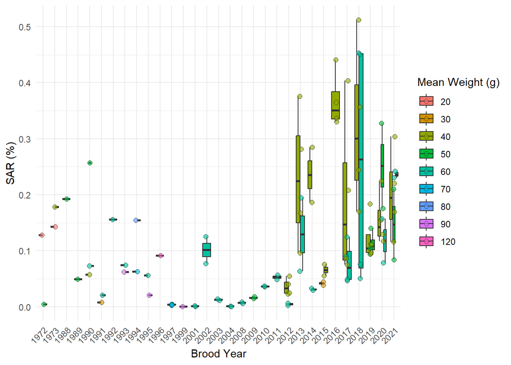

Figure 9: Smolt-adult return calcualted from the raw release and return data across brood years and mean weight release groups.

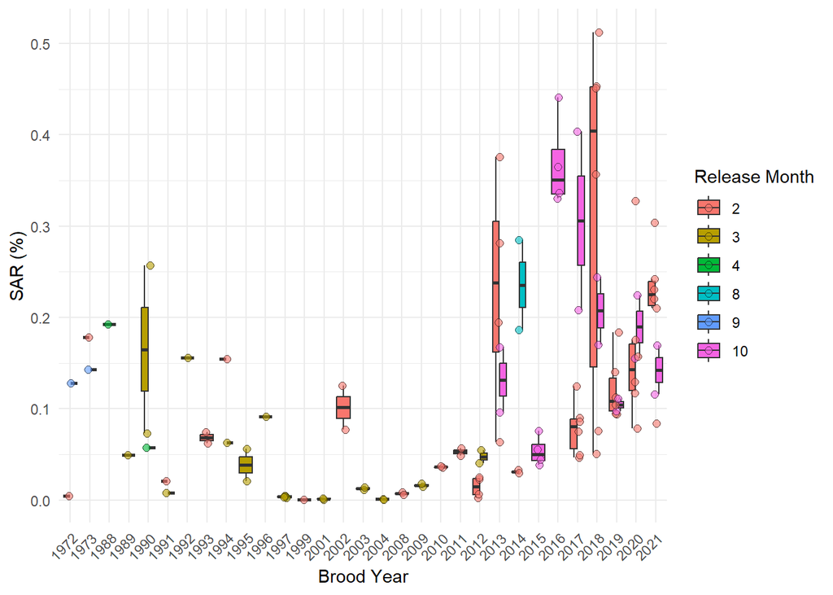

Figure 10: Smolt-adult return calcualted from the raw release and return data across brood years and release month.

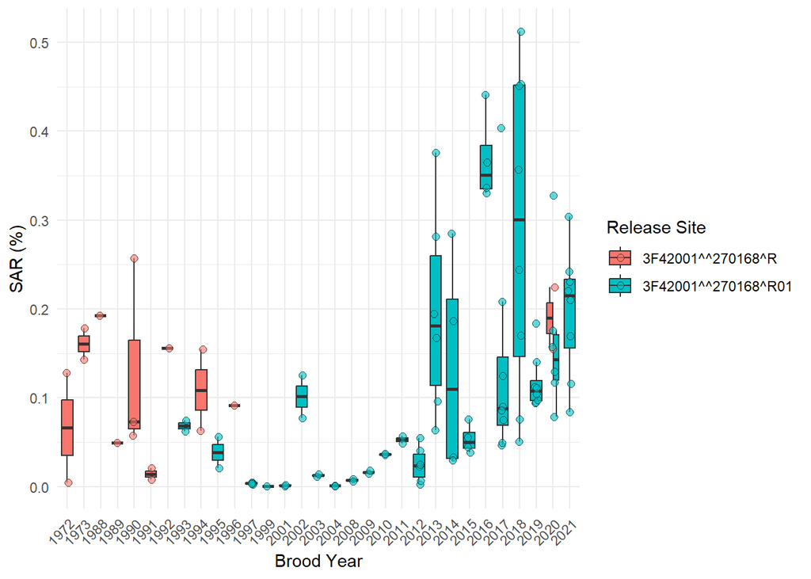

Figure 11: Smolt-adult return calcualted from the raw release and return data across brood years and release sites.

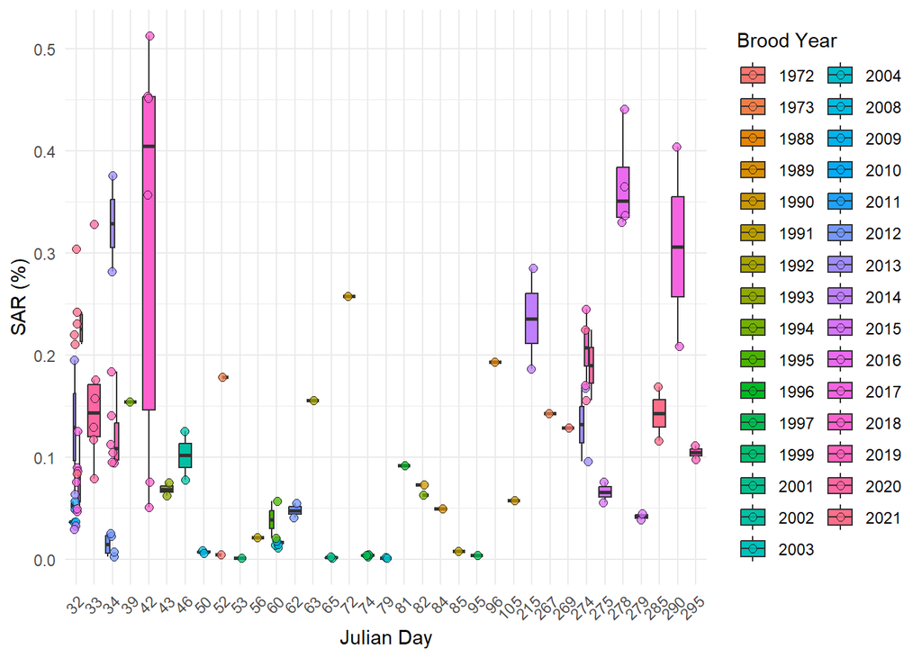

Figure 12: Smolt-adult return calcualted from the raw release and return data across brood years and julian days.

```r
### hatchery sar
hatch_plots <-fate_plots(fate_type = "hatchery", rec_type = hatcheries)

print(hatch_plots$rel_size) # sar by brood year & mean wt
print(hatch_plots$rel_month) # sar by brood year & release month
print(hatch_plots$rel_loc) # sar by release location
print(hatch_plots$rel_jday) # sar by release timing (jday)
```

#### 2.3.1.2 Spawngr SAR Figures

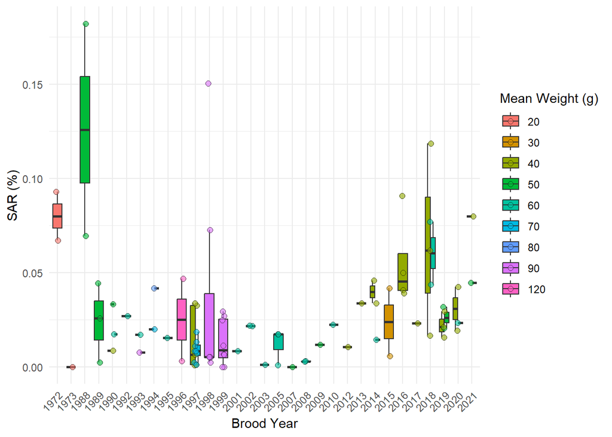

Figure 13: Smolt-adult return calcualted from the raw release and return data across brood years and mean weight release groups.

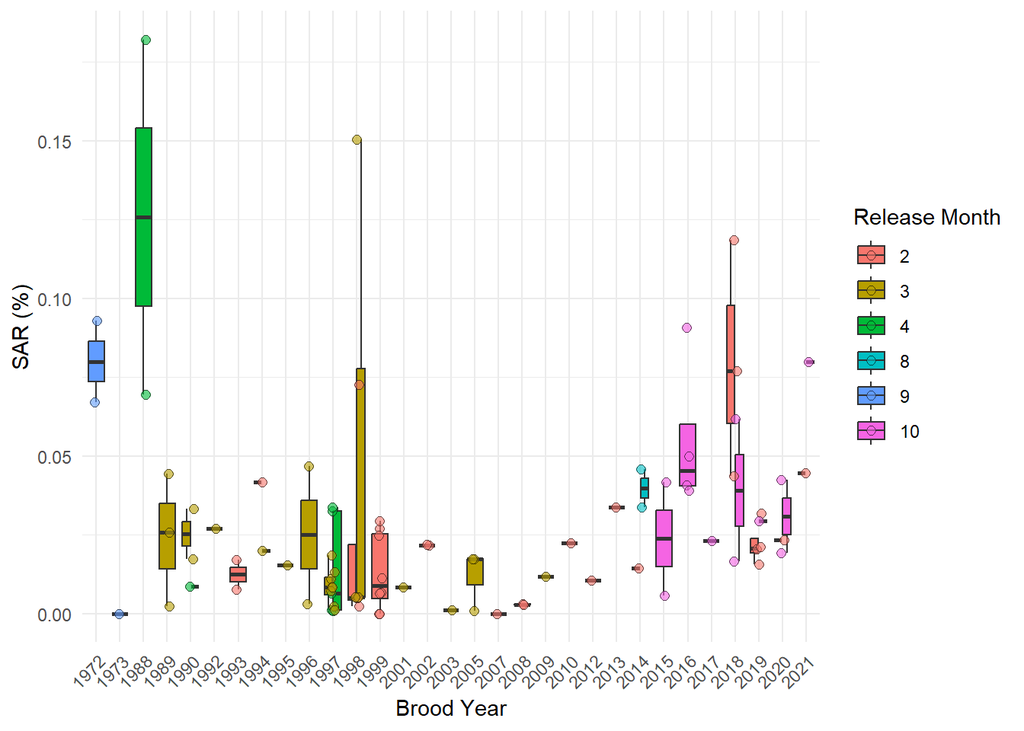

Figure 14: Smolt-adult return calcualted from the raw release and return data across brood years and release month.

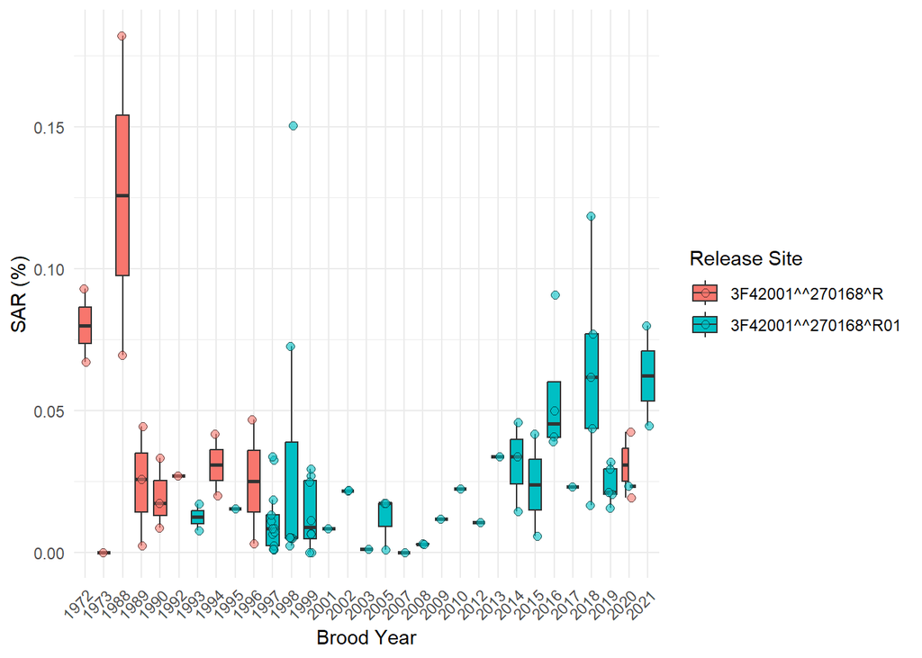

Figure 15: Smolt-adult return calcualted from the raw release and return data across brood years and release sites.

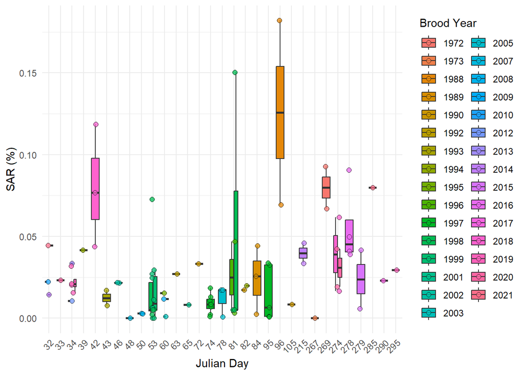

Figure 16: Smolt-adult return calcualted from the raw release and return data across brood years and julian days.

```r
### spawngr sar
# sar by brood year & mean wt
spawngr_plots <-fate_plots(fate_type = "spawngr", rec_type = spawngr_recover)

print(spawngr_plots$rel_size) # sar by brood year & mean wt
print(spawngr_plots$rel_month) # sar by brood year & release month
print(spawngr_plots$rel_loc) # sar by release location
print(spawngr_plots$rel_jday) # sar by release timing (jday)
```

#### 2.3.1.3 Fishery SAR Figures

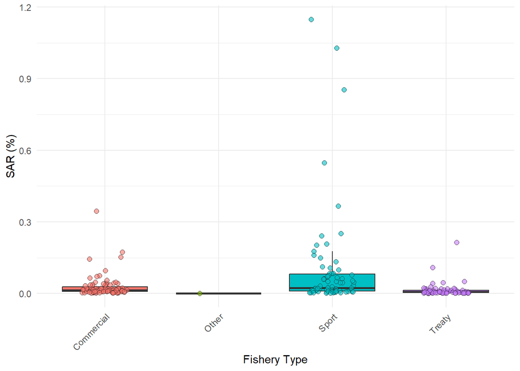

Figure 17: Smolt-adult return calcualted for each fishery type.

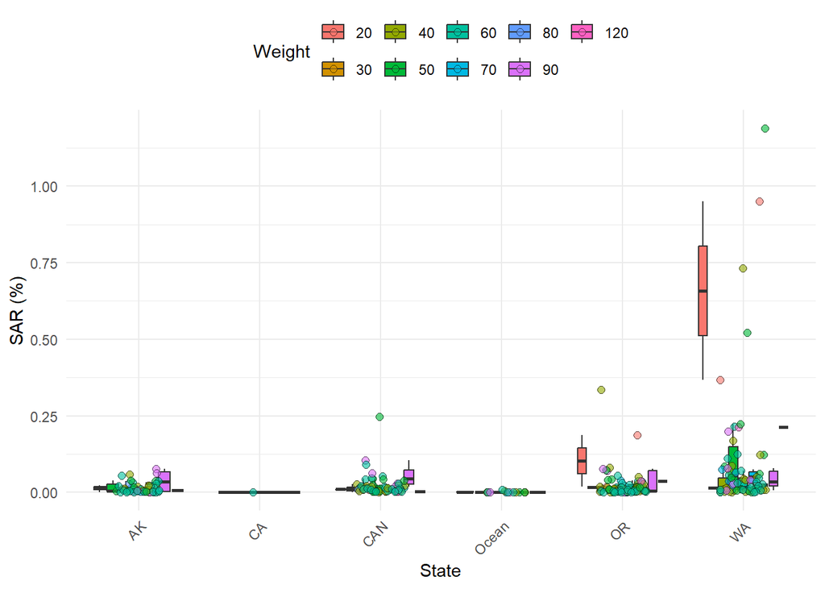

Figure 18: Smolt-adult return calcualted by state landed

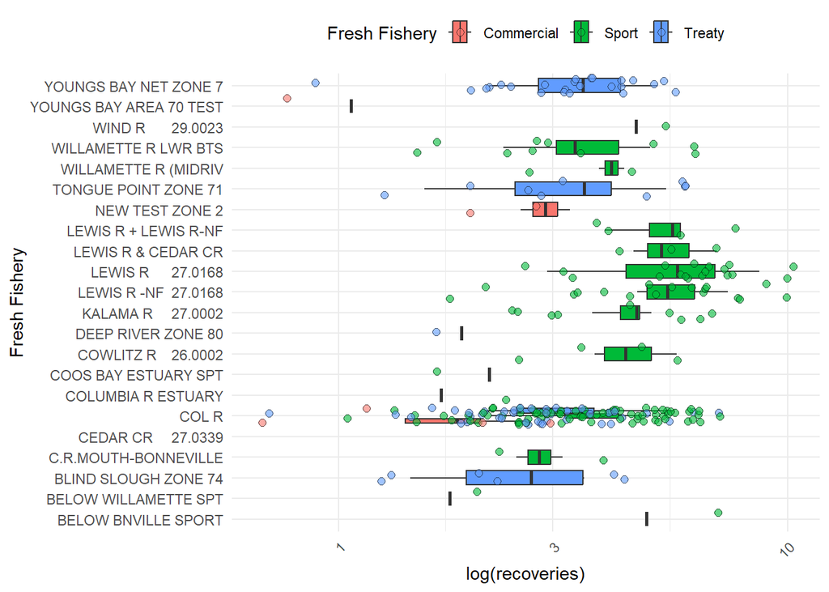

Figure 19: Log of estimated recoveries for freshwater fisheries.

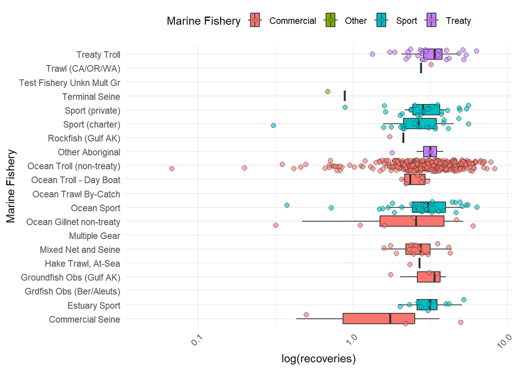

Figure 20: Log of estimated recoveries for marine fisheries.

```r
### fishery sar
fishery_plots <-fate_plots(fate_type = "fishery", rec_type = fishery_recover)

print(fishery_plots$fleet_fishery)
print(fishery_plots$state_fishery)
print(fishery_plots$stem_trib_fishery)
print(fishery_plots$marine_fishery)
```

### 2.3.2 Tables

#### 2.3.2.1 Hatchery SAR table

```r
sar_df_fates[,c("species","brood_year","release_location_code","recovery_location_code",
                "first_release_date_month","jday","avg_weight","releases","sar","fate")]%>%
  filter(., fate == "hatchery" & recovery_location_code %in% hatcheries) %>%
  rename("month" = first_release_date_month) %>%
  arrange(brood_year, month, avg_weight) %>%
  select(-c(brood_year,fate)) %>%
  mutate(sar = sar*100) %>%
  kbl(row.names = NA) %>%
  kable_classic(position="left",full_width = F, html_font = "Cambria") %>%
  kable_styling(bootstrap_options = c("condensed")) %>%
  scroll_box(height = "400px") %>%
  pack_rows(index = table(filter(sar_df_fates, fate=="hatchery" & recovery_location_code %in% hatcheries)$brood_year))
```

Table 9: Smolt-adult return calculated across brood years, mean weight-at-release, and time at release for hatchery fates.

| species | release_location_code | recovery_location_code | month | jday | avg_weight | releases | sar |
| --- | --- | --- | --- | --- | --- | --- | --- |
| **1972** |  |  |  |  |  |  |  |
| 1 | 3F42001^^270168^R | 3F42001^^270430^H | 2 | 52 | 50 | 94392 | 0.0042489 |
| 1 | 3F42001^^270168^R | 3F42001^^270430^H | 9 | 269 | 20 | 104097 | 0.1282567 |
| **1973** |  |  |  |  |  |  |  |
| 1 | 3F42001^^270168^R | 3F42001^^270430^H | 2 | 52 | 40 | 114907 | 0.1780857 |
| 1 | 3F42001^^270168^R | 3F42001^^270430^H | 9 | 267 | 20 | 163504 | 0.1428622 |
| **1988** |  |  |  |  |  |  |  |
| 1 | 3F42001^^270168^R | 3F42001^^270168^H | 4 | 96 | 50 | 330600 | 0.1927474 |
| **1989** |  |  |  |  |  |  |  |
| 1 | 3F42001^^270168^R | 3F42001^^270168^H | 3 | 84 | 50 | 969800 | 0.0492517 |
| **1990** |  |  |  |  |  |  |  |
| 1 | 3F42001^^270168^R | 3F42001^^270168^H | 3 | 72 | 50 | 916100 | 0.2572386 |
| 1 | 3F42001^^270168^R | 3F42001^^270168^H | 3 | 82 | 60 | 916100 | 0.0728454 |
| 1 | 3F42001^^270168^R | 3F42001^^270168^H | 4 | 105 | 40 | 327850 | 0.0574814 |
| **1991** |  |  |  |  |  |  |  |
| 1 | 3F42001^^270168^R | 3F42001^^270168^H | 2 | 56 | 60 | 660000 | 0.0208980 |
| 1 | 3F42001^^270168^R | 3F42001^^270168^H | 3 | 85 | 30 | 401000 | 0.0076510 |
| **1992** |  |  |  |  |  |  |  |
| 1 | 3F42001^^270168^R | 3F42001^^270168^H | 3 | 63 | 60 | 1335900 | 0.1556868 |
| **1993** |  |  |  |  |  |  |  |
| 1 | 3F42001^^270168^R01 | 3F42001^^270168^H | 2 | 43 | 60 | 420092 | 0.0746099 |
| 1 | 3F42001^^270168^R01 | 3F42001^^270168^H | 2 | 43 | 90 | 420092 | 0.0621260 |
| **1994** |  |  |  |  |  |  |  |
| 1 | 3F42001^^270168^R | 3F42001^^270168^H | 2 | 39 | 80 | 666900 | 0.1543164 |
| 1 | 3F42001^^270168^R | 3F42001^^270168^H | 3 | 82 | 70 | 455500 | 0.0629810 |
| **1995** |  |  |  |  |  |  |  |
| 1 | 3F42001^^270168^R01 | 3F42001^^270168^H | 3 | 60 | 60 | 952868 | 0.0564026 |
| 1 | 3F42001^^270168^R01 | 3F42001^^270168^H | 3 | 60 | 90 | 952868 | 0.0206854 |
| **1996** |  |  |  |  |  |  |  |
| 1 | 3F42001^^270168^R | 3F42001^^270168^H | 3 | 81 | 120 | 952441 | 0.0914603 |

[output cut: 106 more lines]

#### 2.3.2.2 Spawngr SAR Table

```r
sar_df_fates[,c("species","brood_year","release_location_code","recovery_location_code",
                "first_release_date_month","jday","avg_weight","releases","sar","fate")]%>%
  filter(., fate == "spawngr" & recovery_location_code %in% spawngr_recover) %>%
  rename("month" = first_release_date_month) %>%
  arrange(brood_year, month, avg_weight) %>%
  select(-c(brood_year,fate)) %>%
  mutate(sar = sar*100) %>%
  kbl(row.names = NA) %>%
  kable_classic(position="left",full_width = F, html_font = "Cambria") %>%
  kable_styling(bootstrap_options = c("condensed")) %>%
  scroll_box(height = "400px") %>%
  pack_rows(index = table(filter(sar_df_fates, fate=="spawngr" & recovery_location_code %in% spawngr_recover)$brood_year))
```

Table 10: Smolt-adult return calculated across brood years, mean weight-at-release, and time at release for spawngr fates.

| species | release_location_code | recovery_location_code | month | jday | avg_weight | releases | sar |
| --- | --- | --- | --- | --- | --- | --- | --- |
| **1972** |  |  |  |  |  |  |  |
| 1 | 3F42001^^270168^R | 3F42001^^270168^R | 9 | 269 | 20 | 104097 | 0.0928161 |
| 1 | 3F42001^^270168^R | 3F42001^^270430^R | 9 | 269 | 20 | 104097 | 0.0670498 |
| **1973** |  |  |  |  |  |  |  |
| 1 | 3F42001^^270168^R | 3F42001^^270168^R | 9 | 267 | 20 | 163504 | 0.0000000 |
| **1988** |  |  |  |  |  |  |  |
| 1 | 3F42001^^270168^R | 3F42001^^270168^R | 4 | 96 | 50 | 330600 | 0.0693740 |
| 1 | 3F42001^^270168^R | 3F42001^^270168^R71 | 4 | 96 | 50 | 330600 | 0.1820704 |
| **1989** |  |  |  |  |  |  |  |
| 1 | 3F42001^^270168^R | 3F42001^^270002^R | 3 | 84 | 50 | 969800 | 0.0024004 |
| 1 | 3F42001^^270168^R | 3F42001^^270168^R | 3 | 84 | 50 | 969800 | 0.0443207 |
| 1 | 3F42001^^270168^R | 3F42001^^270168^R71 | 3 | 84 | 50 | 969800 | 0.0257682 |
| **1990** |  |  |  |  |  |  |  |
| 1 | 3F42001^^270168^R | 3F42001^^270168^R | 3 | 72 | 50 | 916100 | 0.0332216 |
| 1 | 3F42001^^270168^R | 3F42001^^270168^R | 3 | 82 | 60 | 916100 | 0.0173840 |
| 1 | 3F42001^^270168^R | 3F42001^^270168^R | 4 | 105 | 40 | 327850 | 0.0085244 |
| **1992** |  |  |  |  |  |  |  |
| 1 | 3F42001^^270168^R | 3F42001^^270168^R | 3 | 63 | 60 | 1335900 | 0.0270938 |
| **1993** |  |  |  |  |  |  |  |
| 1 | 3F42001^^270168^R01 | 3F42001^^270168^R71 | 2 | 43 | 60 | 420092 | 0.0171232 |
| 1 | 3F42001^^270168^R01 | 3F42001^^270168^R71 | 2 | 43 | 90 | 420092 | 0.0077005 |
| **1994** |  |  |  |  |  |  |  |
| 1 | 3F42001^^270168^R | 3F42001^^270168^R71 | 2 | 39 | 80 | 666900 | 0.0416028 |
| 1 | 3F42001^^270168^R | 3F42001^^270168^R71 | 3 | 82 | 70 | 455500 | 0.0199588 |
| **1995** |  |  |  |  |  |  |  |
| 1 | 3F42001^^270168^R01 | 3F42001^^270168^R71 | 3 | 60 | 60 | 952868 | 0.0153061 |
| **1996** |  |  |  |  |  |  |  |
| 1 | 3F42001^^270168^R | 3F42001^^270168^R71 | 3 | 81 | 120 | 952441 | 0.0468238 |
| 1 | 3F42001^^270168^R | 3F42001^^270168^R71 | 3 | 81 | 120 | 952441 | 0.0031853 |
| **1997** |  |  |  |  |  |  |  |

[output cut: 87 more lines]